# World Population Trend and CO2 Emission

Author

Noella Umutoni

# Data import and understanding

I loaded the two datasets and checked their columns and sizes.

```r
library(ggplot2)
pop_raw <- read.csv("data/world_population.csv", check.names=TRUE)
co2_raw <- read.csv("data/CO2_emission.csv", check.names=TRUE)
cat("Population:", nrow(pop_raw), "rows and", ncol(pop_raw), "columns\n")
```

```
Population: 234 rows and 17 columns
```

```r
cat("CO2:", nrow(co2_raw), "rows and", ncol(co2_raw), "columns\n")
```

```
CO2: 215 rows and 35 columns
```

```r
cat("Population columns:\n"); print(names(pop_raw))
```

```
Population columns:
```

```
 [1] "Rank"                        "CCA3"
 [3] "Country.Territory"           "Capital"
 [5] "Continent"                   "X2022.Population"
 [7] "X2020.Population"            "X2015.Population"
 [9] "X2010.Population"            "X2000.Population"
[11] "X1990.Population"            "X1980.Population"
[13] "X1970.Population"            "Area..km.."
[15] "Density..per.km.."           "Growth.Rate"
[17] "World.Population.Percentage"
```

```r
cat("CO2 columns:\n"); print(names(co2_raw))
```

```
CO2 columns:
```

```
 [1] "Country.Name"   "country_code"   "Region"         "Indicator.Name"
 [5] "X1990"          "X1991"          "X1992"          "X1993"
 [9] "X1994"          "X1995"          "X1996"          "X1997"
[13] "X1998"          "X1999"          "X2000"          "X2001"
[17] "X2002"          "X2003"          "X2004"          "X2005"
[21] "X2006"          "X2007"          "X2008"          "X2009"
[25] "X2010"          "X2011"          "X2012"          "X2013"
[29] "X2014"          "X2015"          "X2016"          "X2017"
[33] "X2018"          "X2019"          "X2019.1"
```

```r
knitr::kable(head(pop_raw, 5), caption="First five population rows")
```

First five population rows

| Rank | CCA3 | Country.Territory | Capital | Continent | X2022.Population | X2020.Population | X2015.Population | X2010.Population | X2000.Population | X1990.Population | X1980.Population | X1970.Population | Area..km.. | Density..per.km.. | Growth.Rate | World.Population.Percentage |
| --- | --- | --- | --- | --- | --- | --- | --- | --- | --- | --- | --- | --- | --- | --- | --- | --- |
| 36 | AFG | Afghanistan | Kabul | Asia | 41128771 | 38972230 | 33753499 | 28189672 | 19542982 | 10694796 | 12486631 | 10752971 | 652230 | 63.0587 | 1.0257 | 0.52 |
| 138 | ALB | Albania | Tirana | Europe | 2842321 | 2866849 | 2882481 | 2913399 | 3182021 | 3295066 | 2941651 | 2324731 | 28748 | 98.8702 | 0.9957 | 0.04 |
| 34 | DZA | Algeria | Algiers | Africa | 44903225 | 43451666 | 39543154 | 35856344 | 30774621 | 25518074 | 18739378 | 13795915 | 2381741 | 18.8531 | 1.0164 | 0.56 |
| 213 | ASM | American Samoa | Pago Pago | Oceania | 44273 | 46189 | 51368 | 54849 | 58230 | 47818 | 32886 | 27075 | 199 | 222.4774 | 0.9831 | 0.00 |
| 203 | AND | Andorra | Andorra la Vella | Europe | 79824 | 77700 | 71746 | 71519 | 66097 | 53569 | 35611 | 19860 | 468 | 170.5641 | 1.0100 | 0.00 |

```r
knitr::kable(tail(pop_raw, 10), caption="Last ten population rows")
```

Last ten population rows

|  | Rank | CCA3 | Country.Territory | Capital | Continent | X2022.Population | X2020.Population | X2015.Population | X2010.Population | X2000.Population | X1990.Population | X1980.Population | X1970.Population | Area..km.. | Density..per.km.. | Growth.Rate | World.Population.Percentage |
| --- | --- | --- | --- | --- | --- | --- | --- | --- | --- | --- | --- | --- | --- | --- | --- | --- | --- |
| 225 | 43 | UZB | Uzbekistan | Tashkent | Asia | 34627652 | 33526656 | 30949417 | 28614227 | 24925554 | 20579100 | 15947129 | 12011361 | 447400 | 77.3975 | 1.0160 | 0.43 |
| 226 | 181 | VUT | Vanuatu | Port-Vila | Oceania | 326740 | 311685 | 276438 | 245453 | 192074 | 150882 | 118156 | 87019 | 12189 | 26.8061 | 1.0238 | 0.00 |
| 227 | 234 | VAT | Vatican City | Vatican City | Europe | 510 | 520 | 564 | 596 | 651 | 700 | 733 | 752 | 1 | 510.0000 | 0.9980 | 0.00 |
| 228 | 51 | VEN | Venezuela | Caracas | South America | 28301696 | 28490453 | 30529716 | 28715022 | 24427729 | 19750579 | 15210443 | 11355475 | 916445 | 30.8820 | 1.0036 | 0.35 |
| 229 | 16 | VNM | Vietnam | Hanoi | Asia | 98186856 | 96648685 | 92191398 | 87411012 | 79001142 | 66912613 | 52968270 | 41928849 | 331212 | 296.4472 | 1.0074 | 1.23 |
| 230 | 226 | WLF | Wallis and Futuna | Mata-Utu | Oceania | 11572 | 11655 | 12182 | 13142 | 14723 | 13454 | 11315 | 9377 | 142 | 81.4930 | 0.9953 | 0.00 |
| 231 | 172 | ESH | Western Sahara | El Aaiún | Africa | 575986 | 556048 | 491824 | 413296 | 270375 | 178529 | 116775 | 76371 | 266000 | 2.1654 | 1.0184 | 0.01 |
| 232 | 46 | YEM | Yemen | Sanaa | Asia | 33696614 | 32284046 | 28516545 | 24743946 | 18628700 | 13375121 | 9204938 | 6843607 | 527968 | 63.8232 | 1.0217 | 0.42 |
| 233 | 63 | ZMB | Zambia | Lusaka | Africa | 20017675 | 18927715 | 16248230 | 13792086 | 9891136 | 7686401 | 5720438 | 4281671 | 752612 | 26.5976 | 1.0280 | 0.25 |
| 234 | 74 | ZWE | Zimbabwe | Harare | Africa | 16320537 | 15669666 | 14154937 | 12839771 | 11834676 | 10113893 | 7049926 | 5202918 | 390757 | 41.7665 | 1.0204 | 0.20 |

```r
str(pop_raw)
```

```
'data.frame':   234 obs. of  17 variables:
 $ Rank                       : int  36 138 34 213 203 42 224 201 33 140 ...
 $ CCA3                       : chr  "AFG" "ALB" "DZA" "ASM" ...
 $ Country.Territory          : chr  "Afghanistan" "Albania" "Algeria" "American Samoa" ...
 $ Capital                    : chr  "Kabul" "Tirana" "Algiers" "Pago Pago" ...
 $ Continent                  : chr  "Asia" "Europe" "Africa" "Oceania" ...
 $ X2022.Population           : int  41128771 2842321 44903225 44273 79824 35588987 15857 93763 45510318 2780469 ...
 $ X2020.Population           : int  38972230 2866849 43451666 46189 77700 33428485 15585 92664 45036032 2805608 ...
 $ X2015.Population           : int  33753499 2882481 39543154 51368 71746 28127721 14525 89941 43257065 2878595 ...
 $ X2010.Population           : int  28189672 2913399 35856344 54849 71519 23364185 13172 85695 41100123 2946293 ...
 $ X2000.Population           : int  19542982 3182021 30774621 58230 66097 16394062 11047 75055 37070774 3168523 ...
 $ X1990.Population           : int  10694796 3295066 25518074 47818 53569 11828638 8316 63328 32637657 3556539 ...
 $ X1980.Population           : int  12486631 2941651 18739378 32886 35611 8330047 6560 64888 28024803 3135123 ...
 $ X1970.Population           : int  10752971 2324731 13795915 27075 19860 6029700 6283 64516 23842803 2534377 ...
 $ Area..km..                 : int  652230 28748 2381741 199 468 1246700 91 442 2780400 29743 ...
 $ Density..per.km..          : num  63.1 98.9 18.9 222.5 170.6 ...
 $ Growth.Rate                : num  1.026 0.996 1.016 0.983 1.01 ...
 $ World.Population.Percentage: num  0.52 0.04 0.56 0 0 0.45 0 0 0.57 0.03 ...
```

# Exploratory data analysis and cleaning

## Missing values and duplicates

```r
quality <- data.frame(Dataset=c("Population","CO2"),
 Rows=c(nrow(pop_raw),nrow(co2_raw)),
 Columns=c(ncol(pop_raw),ncol(co2_raw)),
 Duplicate_rows=c(sum(duplicated(pop_raw)),sum(duplicated(co2_raw))),
 Missing_cells=c(sum(is.na(pop_raw)),sum(is.na(co2_raw))))
knitr::kable(quality, caption="Initial data quality")
```

Initial data quality

| Dataset | Rows | Columns | Duplicate_rows | Missing_cells |
| --- | --- | --- | --- | --- |
| Population | 234 | 17 | 0 | 0 |
| CO2 | 215 | 35 | 0 | 770 |

```r
knitr::kable(data.frame(Variable=names(pop_raw), Missing=colSums(is.na(pop_raw))), caption="Population missingness by variable")
```

Population missingness by variable

|  | Variable | Missing |
| --- | --- | --- |
| Rank | Rank | 0 |
| CCA3 | CCA3 | 0 |
| Country.Territory | Country.Territory | 0 |
| Capital | Capital | 0 |
| Continent | Continent | 0 |
| X2022.Population | X2022.Population | 0 |
| X2020.Population | X2020.Population | 0 |
| X2015.Population | X2015.Population | 0 |
| X2010.Population | X2010.Population | 0 |
| X2000.Population | X2000.Population | 0 |
| X1990.Population | X1990.Population | 0 |
| X1980.Population | X1980.Population | 0 |
| X1970.Population | X1970.Population | 0 |
| Area..km.. | Area..km.. | 0 |
| Density..per.km.. | Density..per.km.. | 0 |
| Growth.Rate | Growth.Rate | 0 |
| World.Population.Percentage | World.Population.Percentage | 0 |

```r
knitr::kable(data.frame(Variable=names(co2_raw), Missing=colSums(is.na(co2_raw))), caption="CO2 missingness by variable")
```

CO2 missingness by variable

|  | Variable | Missing |
| --- | --- | --- |
| Country.Name | Country.Name | 0 |
| country_code | country_code | 0 |
| Region | Region | 0 |
| Indicator.Name | Indicator.Name | 0 |
| X1990 | X1990 | 30 |
| X1991 | X1991 | 29 |
| X1992 | X1992 | 26 |
| X1993 | X1993 | 26 |
| X1994 | X1994 | 26 |
| X1995 | X1995 | 25 |
| X1996 | X1996 | 25 |
| X1997 | X1997 | 25 |
| X1998 | X1998 | 26 |
| X1999 | X1999 | 26 |
| X2000 | X2000 | 25 |
| X2001 | X2001 | 25 |
| X2002 | X2002 | 24 |
| X2003 | X2003 | 24 |
| X2004 | X2004 | 24 |
| X2005 | X2005 | 24 |
| X2006 | X2006 | 24 |
| X2007 | X2007 | 24 |
| X2008 | X2008 | 24 |
| X2009 | X2009 | 24 |
| X2010 | X2010 | 24 |
| X2011 | X2011 | 24 |
| X2012 | X2012 | 24 |
| X2013 | X2013 | 24 |
| X2014 | X2014 | 24 |
| X2015 | X2015 | 24 |
| X2016 | X2016 | 24 |
| X2017 | X2017 | 24 |
| X2018 | X2018 | 24 |
| X2019 | X2019 | 24 |
| X2019.1 | X2019.1 | 24 |

## Clean the data

I removed the repeated 2019 column. I only estimated short gaps between known CO2 values. I kept the other missing values and used the original 2019 data for the main analysis.

```r
pop_clean <- unique(pop_raw)
co2_clean <- unique(co2_raw)
if ("X2019.1" %in% names(co2_clean)) {
  if (identical(co2_clean$X2019, co2_clean$X2019.1)) {
    co2_clean$X2019.1 <- NULL
  }
}
co2_years <- 1990:2019
co2_cols <- paste0("X", co2_years)

# Fill only short missing gaps between known years
fill_short_gaps <- function(x, max_gap=2) {
  x <- as.numeric(x)
  known <- which(!is.na(x))
  if (length(known) < 2) return(x)
  estimated <- approx(x=known, y=x[known], xout=seq_along(x), rule=1)$y
  missing <- which(is.na(x))
  if (!length(missing)) return(x)
  runs <- split(missing, cumsum(c(1, diff(missing)!=1)))
  for (r in runs) {
    if (length(r) <= max_gap && min(r)>min(known) && max(r)<max(known)) x[r] <- estimated[r]
  }
  x
}
co2_interpolated <- co2_clean
co2_interpolated[co2_cols] <- t(apply(co2_clean[co2_cols], 1, fill_short_gaps))
cat("Missing annual CO2 values before:", sum(is.na(co2_clean[co2_cols])), "\n")
```

```
Missing annual CO2 values before: 746
```

```r
cat("Missing annual CO2 values after limited interpolation:", sum(is.na(co2_interpolated[co2_cols])), "\n")
```

```
Missing annual CO2 values after limited interpolation: 744
```

```r
cat("Estimated values:", sum(is.na(co2_clean[co2_cols])) - sum(is.na(co2_interpolated[co2_cols])), "\n")
```

```
Estimated values: 2
```

## Check outliers using boxplots

I used boxplots to check numerical variables. I left out Rank because it is a position, not a measurement. I did not remove unusual values without evidence of an error.

```r
quantitative <- pop_clean[sapply(pop_clean, is.numeric)]
quantitative$Rank <- NULL
outlier_summary <- data.frame(
 Variable=names(quantitative),
 Potential_outliers=sapply(quantitative, function(x) length(boxplot.stats(x)$out)))
knitr::kable(outlier_summary, caption="Population outliers by IQR rule")
```

Population outliers by IQR rule

|  | Variable | Potential_outliers |
| --- | --- | --- |
| X2022.Population | X2022.Population | 25 |
| X2020.Population | X2020.Population | 26 |
| X2015.Population | X2015.Population | 27 |
| X2010.Population | X2010.Population | 25 |
| X2000.Population | X2000.Population | 28 |
| X1990.Population | X1990.Population | 31 |
| X1980.Population | X1980.Population | 32 |
| X1970.Population | X1970.Population | 29 |
| Area..km.. | Area..km.. | 28 |
| Density..per.km.. | Density..per.km.. | 22 |
| Growth.Rate | Growth.Rate | 3 |
| World.Population.Percentage | World.Population.Percentage | 25 |

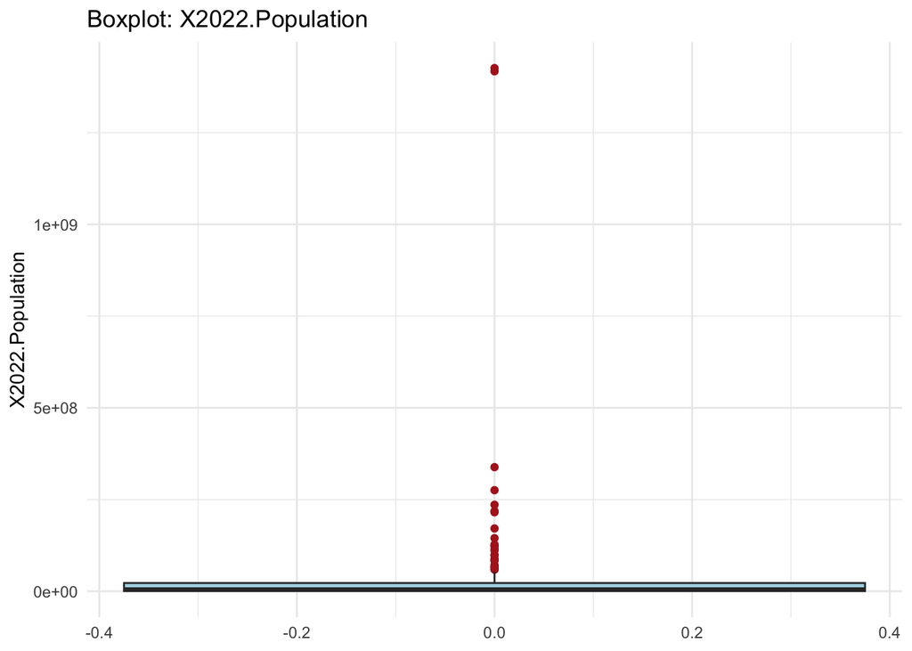

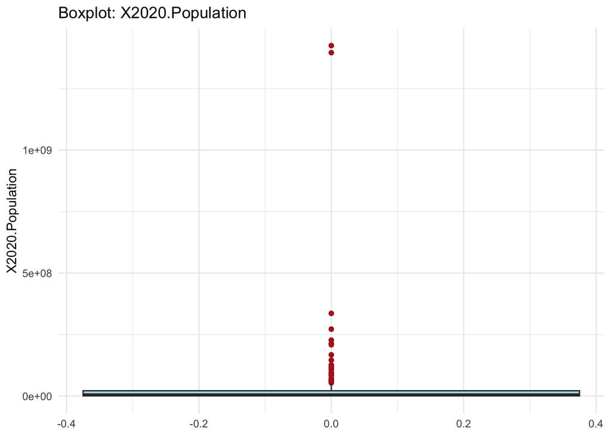

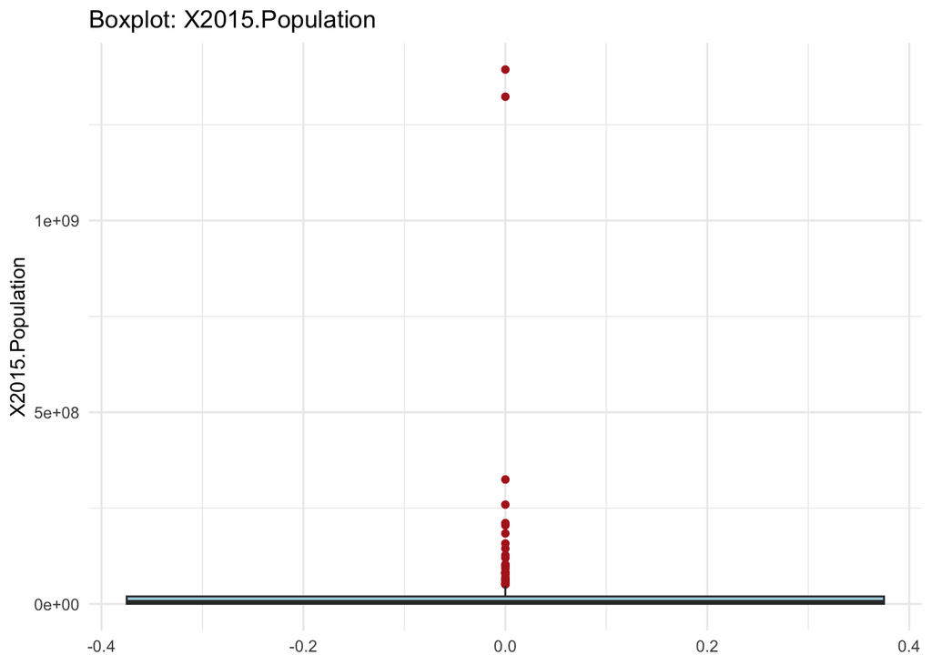

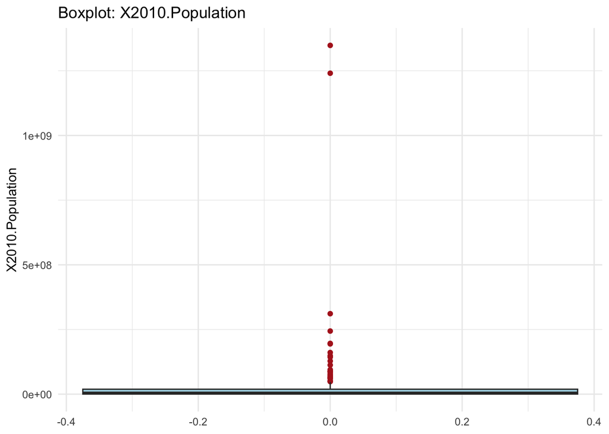

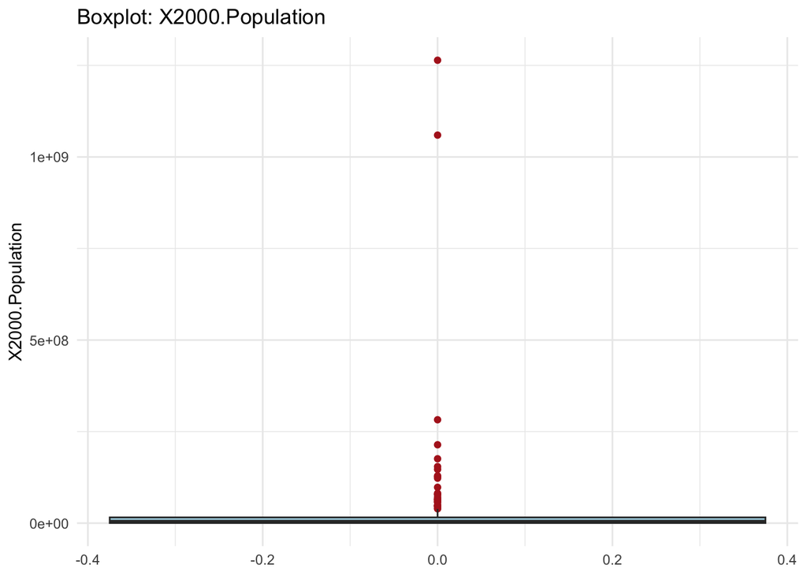

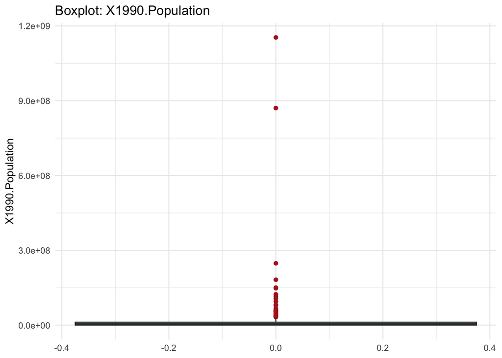

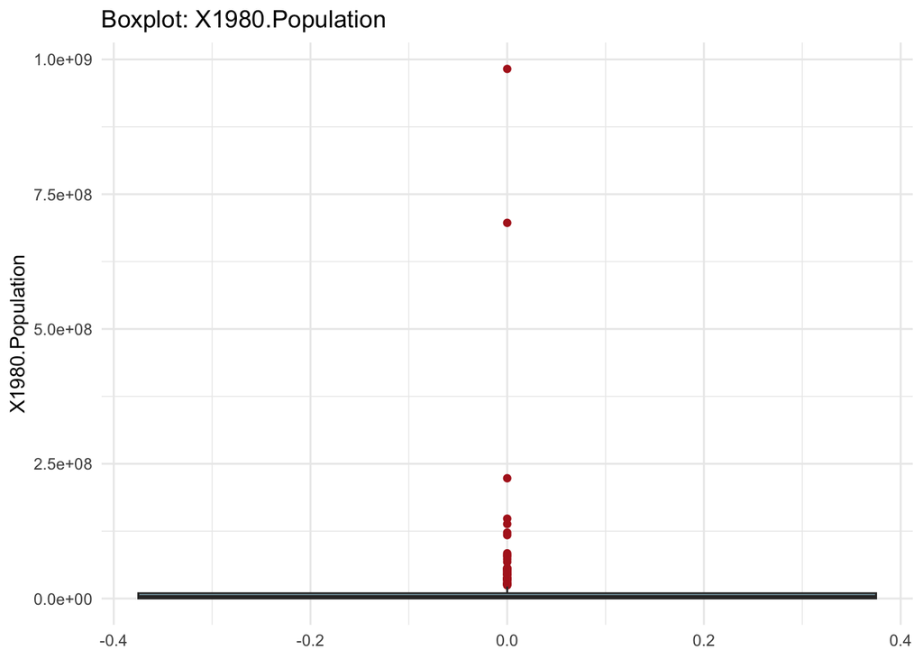

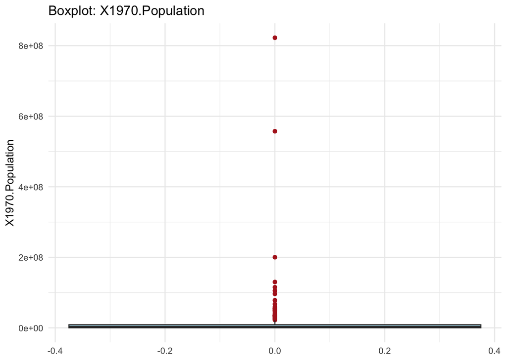

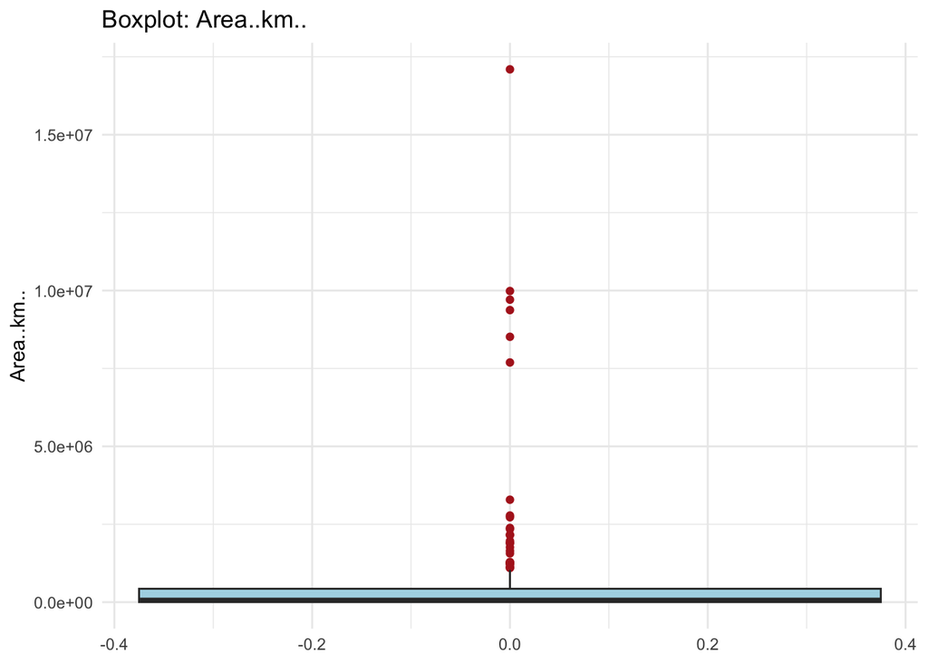

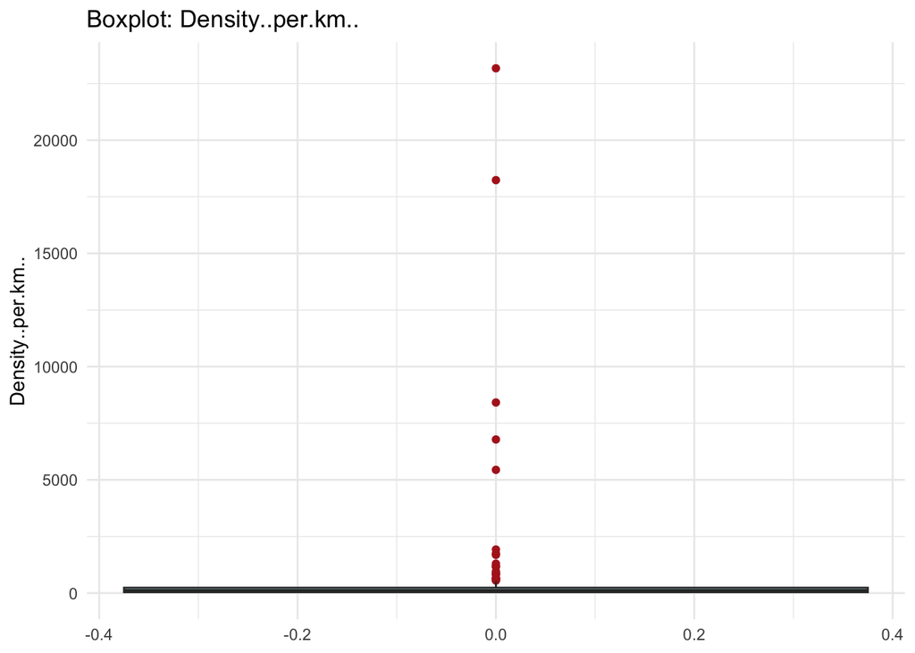

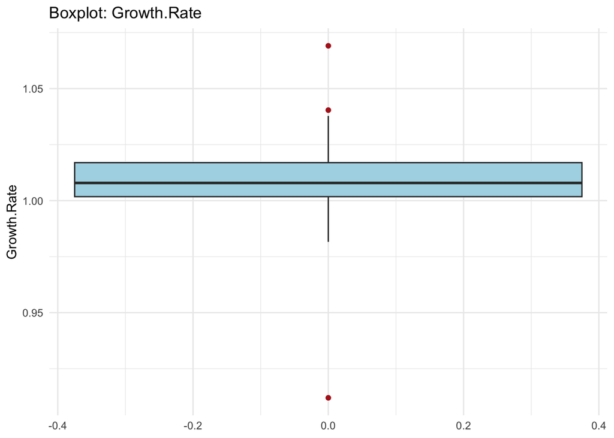

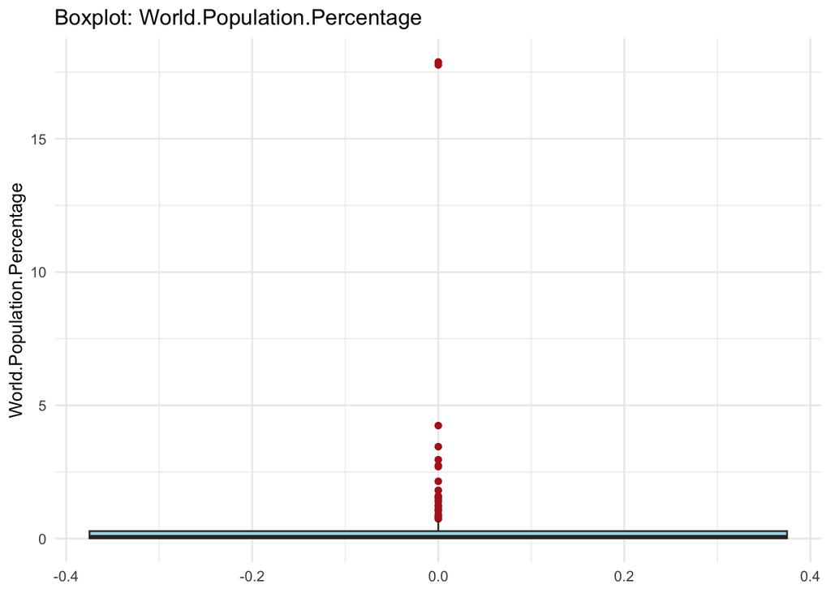

```r
for (v in names(quantitative)) {
  print(ggplot(quantitative, aes(y=.data[[v]])) +
    geom_boxplot(fill="lightblue", outlier.color="firebrick") +
    labs(title=paste("Boxplot:",v), y=v, x=NULL) + theme_minimal())
}
```

For the CO2 dataset, inspect the distribution of the observed 2019 emissions per person.

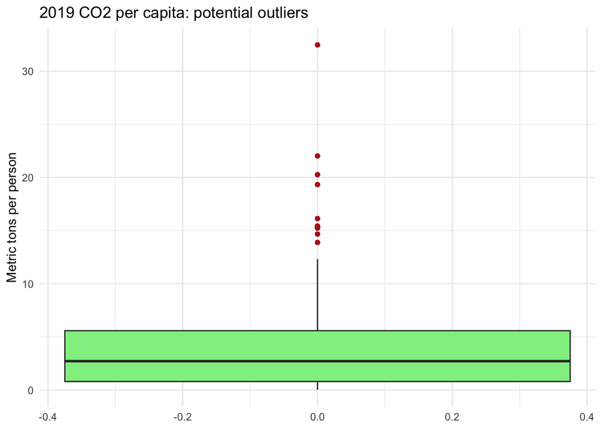

```r
ggplot(co2_clean, aes(y=X2019)) +
  geom_boxplot(fill="lightgreen", na.rm=TRUE, outlier.color="firebrick") +
  labs(title="2019 CO2 per capita: potential outliers", y="Metric tons per person") + theme_minimal()
```

## Summary statistics

```r
area_col <- grep("^Area", names(pop_clean), value=TRUE)[1]
density_col <- grep("^Density", names(pop_clean), value=TRUE)[1]
summary(pop_clean[c("X2022.Population",area_col,density_col,"Growth.Rate","World.Population.Percentage")])
```

```
 X2022.Population      Area..km..       Density..per.km..    Growth.Rate
 Min.   :5.100e+02   Min.   :       1   Min.   :2.610e-02   Min.   :0.912
 1st Qu.:4.197e+05   1st Qu.:    2650   1st Qu.:3.842e+01   1st Qu.:1.002
 Median :5.560e+06   Median :   81200   Median :9.535e+01   Median :1.008
 Mean   :3.407e+07   Mean   :  581449   Mean   :4.521e+02   Mean   :1.010
 3rd Qu.:2.248e+07   3rd Qu.:  430426   3rd Qu.:2.389e+02   3rd Qu.:1.017
 Max.   :1.426e+09   Max.   :17098242   Max.   :2.317e+04   Max.   :1.069
 World.Population.Percentage
 Min.   : 0.0000
 1st Qu.: 0.0100
 Median : 0.0700
 Mean   : 0.4271
 3rd Qu.: 0.2800
 Max.   :17.8800
```

```r
summary(co2_clean$X2019)
```

```
    Min.  1st Qu.   Median     Mean  3rd Qu.     Max.      NAs
 0.03699  0.80176  2.71762  4.11514  5.58516 32.47447       24
```

# Create a projected 2030 population variable

I estimated the 2030 population using the 2022 population and growth rate. I assumed the growth rate stays the same for eight years.

```r
# Population in 2022
P <- pop_clean$X2022.Population

# Annual growth rate
r <- log(pop_clean$Growth.Rate)

# Number of years from 2022 to 2030
t <- 8

# Predict population in 2030 using N = P * exp(r * t)
pop_clean$Population_2030 <- round(P * exp(r * t))

# Show the predicted population
# Show the first 15 countries
knitr::kable(
  head(pop_clean[, c("Country.Territory",
                     "X2022.Population",
                     "Population_2030")], 15)
)
```

| Country.Territory | X2022.Population | Population_2030 |
| --- | --- | --- |
| Afghanistan | 41128771 | 50385848 |
| Albania | 2842321 | 2746004 |
| Algeria | 44903225 | 51144011 |
| American Samoa | 44273 | 38630 |
| Andorra | 79824 | 86438 |
| Angola | 35588987 | 45610989 |
| Anguilla | 15857 | 16714 |
| Antigua and Barbuda | 93763 | 98203 |
| Argentina | 45510318 | 47438365 |
| Armenia | 2780469 | 2697058 |
| Aruba | 106445 | 105681 |
| Australia | 26177413 | 28323942 |
| Austria | 8939617 | 9083656 |
| Azerbaijan | 10358074 | 10728343 |
| Bahamas | 409984 | 427013 |

# Population and CO2 trends

## Top ten countries in 2022

```r
top10 <- head(pop_clean[order(-pop_clean$X2022.Population),],10)
knitr::kable(top10[c("Country.Territory","X2022.Population")], caption="Top ten populations in 2022")
```

Top ten populations in 2022

|  | Country.Territory | X2022.Population |
| --- | --- | --- |
| 42 | China | 1425887337 |
| 93 | India | 1417173173 |
| 222 | United States | 338289857 |
| 94 | Indonesia | 275501339 |
| 157 | Pakistan | 235824862 |
| 150 | Nigeria | 218541212 |
| 28 | Brazil | 215313498 |
| 17 | Bangladesh | 171186372 |
| 172 | Russia | 144713314 |
| 132 | Mexico | 127504125 |

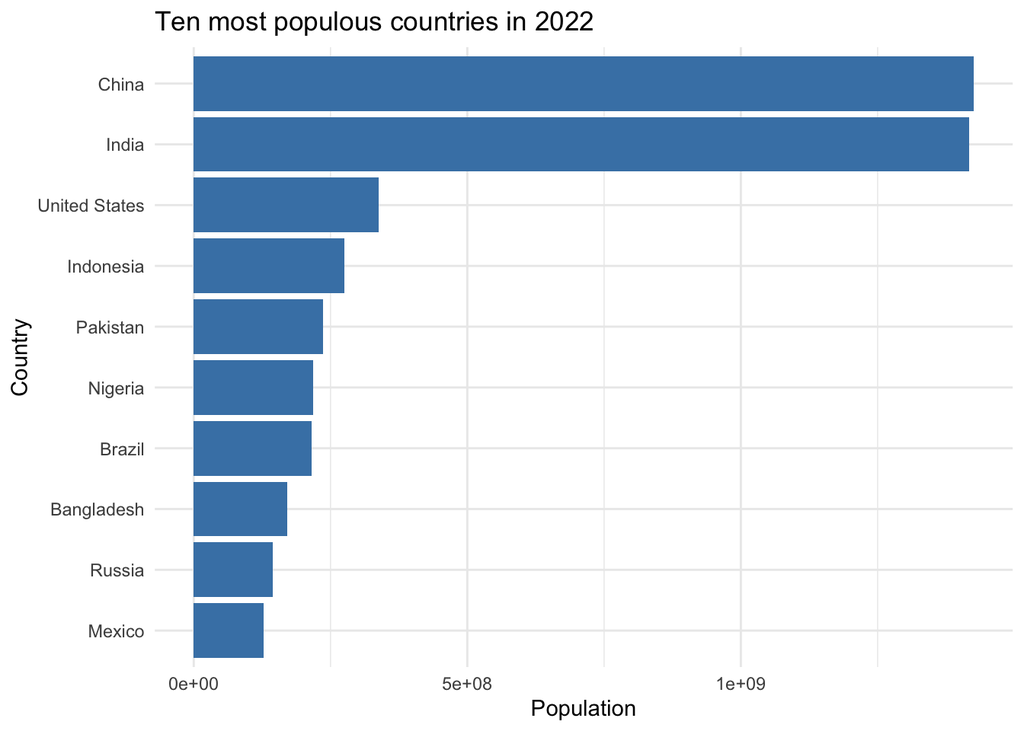

```r
ggplot(top10, aes(x=reorder(Country.Territory,X2022.Population),y=X2022.Population)) +
 geom_col(fill="steelblue") + coord_flip() +
 labs(title="Ten most populous countries in 2022",x="Country",y="Population") + theme_minimal()
```

## Top ten population trends (available benchmark years, 1990–2022)

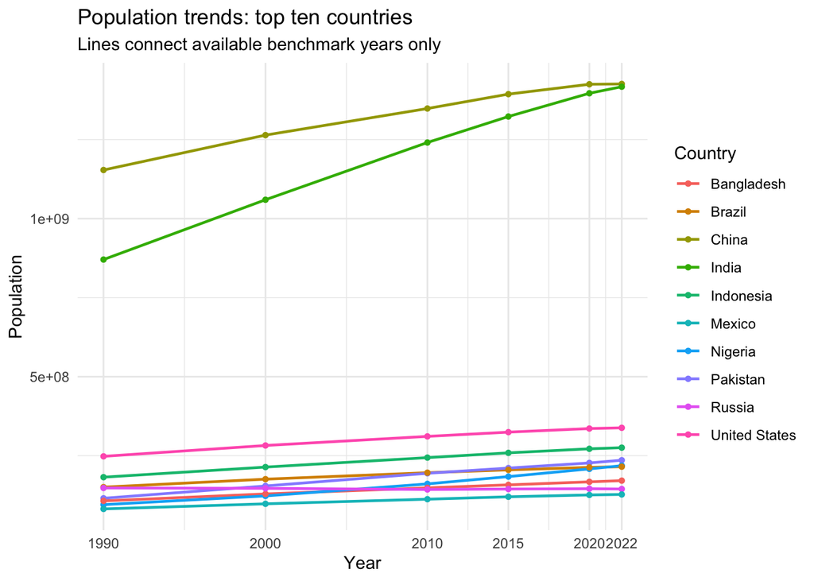

```r
pop_years <- c(1990,2000,2010,2015,2020,2022)
pop_long <- do.call(rbind,lapply(pop_years,function(y) data.frame(
 Country=top10$Country.Territory,Year=y,Population=top10[[paste0("X",y,".Population")]])))
ggplot(pop_long,aes(Year,Population,color=Country,group=Country)) +
 geom_line(linewidth=.8) + geom_point(size=1.2) +
 scale_x_continuous(breaks=pop_years) +
 labs(title="Population trends: top ten countries",subtitle="Lines connect available benchmark years only",y="Population") + theme_minimal()
```

## Top ten CO2 per-capita trends, 1990–2019

I matched countries using their country codes because some country names are written differently in the two files.

```r
merged <- merge(pop_clean,co2_clean,by.x="CCA3",by.y="country_code",all.x=TRUE)
merged_interp <- merge(pop_clean,co2_interpolated,by.x="CCA3",by.y="country_code",all.x=TRUE)
cat("Population rows without a matching CO2 country code:",sum(is.na(merged$X1990) & is.na(merged$Country.Name)),"\n")
```

```
Population rows without a matching CO2 country code: 20
```

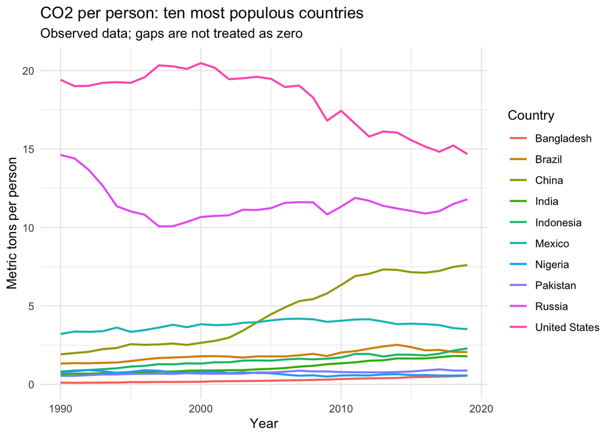

```r
co2_top <- merged[merged$CCA3 %in% top10$CCA3,]
co2_long <- do.call(rbind,lapply(co2_years,function(y) data.frame(
 Country=co2_top$Country.Territory,Year=y,CO2=co2_top[[paste0("X",y)]])))
ggplot(co2_long,aes(Year,CO2,color=Country,group=Country)) +
 geom_line(linewidth=.8,na.rm=TRUE) +
 labs(title="CO2 per person: ten most populous countries",subtitle="Observed data; gaps are not treated as zero",y="Metric tons per person") + theme_minimal()
```

## Check the effect of filling short gaps

```r
obs <- co2_clean[co2_clean$country_code %in% top10$CCA3,]
imp <- co2_interpolated[co2_interpolated$country_code %in% top10$CCA3,]
cat("Observed missing top-ten country-year values:",sum(is.na(obs[co2_cols])),"\n")
```

```
Observed missing top-ten country-year values: 0
```

```r
cat("Missing after limited interpolation:",sum(is.na(imp[co2_cols])),"\n")
```

```
Missing after limited interpolation: 0
```

# Correlation analysis

## Area, density, growth rate and world population share

```r
cor_cols <- c(area_col,density_col,"Growth.Rate","World.Population.Percentage")
cor_matrix <- cor(pop_clean[cor_cols],use="complete.obs")
knitr::kable(round(cor_matrix,3),caption="Pearson correlation matrix")
```

Pearson correlation matrix

|  | Area..km.. | Density..per.km.. | Growth.Rate | World.Population.Percentage |
| --- | --- | --- | --- | --- |
| Area..km.. | 1.000 | -0.063 | -0.014 | 0.453 |
| Density..per.km.. | -0.063 | 1.000 | -0.070 | -0.028 |
| Growth.Rate | -0.014 | -0.070 | 1.000 | -0.021 |
| World.Population.Percentage | 0.453 | -0.028 | -0.021 | 1.000 |

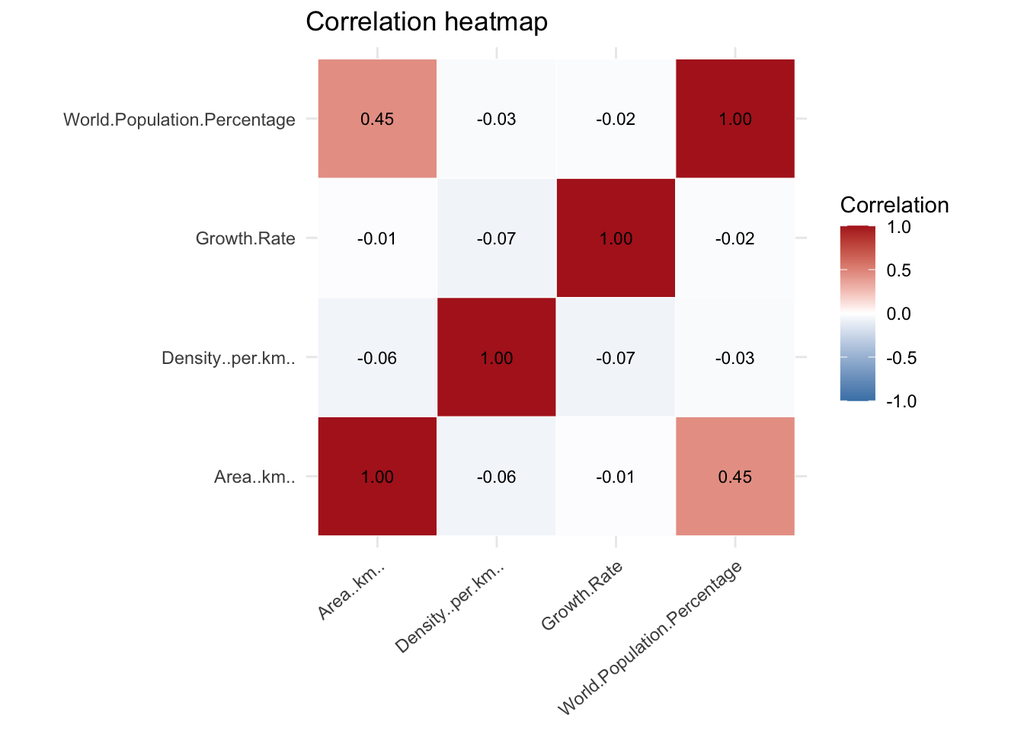

```r
cor_long <- as.data.frame(as.table(cor_matrix))
names(cor_long) <- c("Variable1","Variable2","Correlation")
ggplot(cor_long,aes(Variable1,Variable2,fill=Correlation)) +
 geom_tile(color="white") + geom_text(aes(label=sprintf("%.2f",Correlation)),size=3) +
 scale_fill_gradient2(low="steelblue",mid="white",high="firebrick",midpoint=0,limits=c(-1,1)) +
 coord_equal() + theme_minimal() + theme(axis.text.x=element_text(angle=40,hjust=1)) +
 labs(title="Correlation heatmap",x=NULL,y=NULL)
```

## 2022 population versus observed 2019 CO2 per capita

```r
paired <- merged[complete.cases(merged[c("X2022.Population","X2019")]),]
cat("Paired observations:",nrow(paired),"\n")
```

```
Paired observations: 191
```

```r
cat("Pearson:",cor(paired$X2022.Population,paired$X2019),"\n")
```

```
Pearson: 0.01446026
```

```r
cat("Spearman:",cor(paired$X2022.Population,paired$X2019,method="spearman"),"\n")
```

```
Spearman: -0.1102766
```

```r
fit <- lm(X2019 ~ X2022.Population,data=paired)
summary(fit)
```

```
Call:
lm(formula = X2019 ~ X2022.Population, data = paired)

Residuals:
   Min     1Q Median     3Q    Max
-4.104 -3.311 -1.380  1.486 28.377

Coefficients:
                  Estimate Std. Error t value Pr(>|t|)
(Intercept)      4.096e+00  3.548e-01  11.544   <2e-16 ***
X2022.Population 4.532e-10  2.279e-09   0.199    0.843
---
Signif. codes:  0 '***' 0.001 '**' 0.01 '*' 0.05 '.' 0.1 ' ' 1

Residual standard error: 4.727 on 189 degrees of freedom
Multiple R-squared:  0.0002091, Adjusted R-squared:  -0.005081
F-statistic: 0.03953 on 1 and 189 DF,  p-value: 0.8426
```

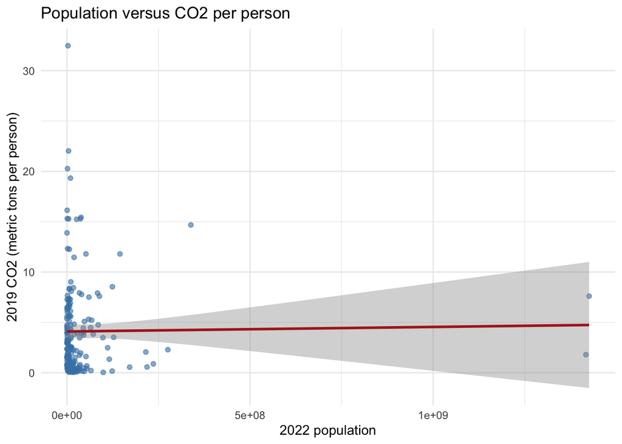

```r
ggplot(paired,aes(X2022.Population,X2019)) +
 geom_point(alpha=.6,color="steelblue") + geom_smooth(method="lm",se=TRUE,color="firebrick") +
 labs(title="Population versus CO2 per person",x="2022 population",y="2019 CO2 (metric tons per person)") + theme_minimal()
```

## Check the regression results

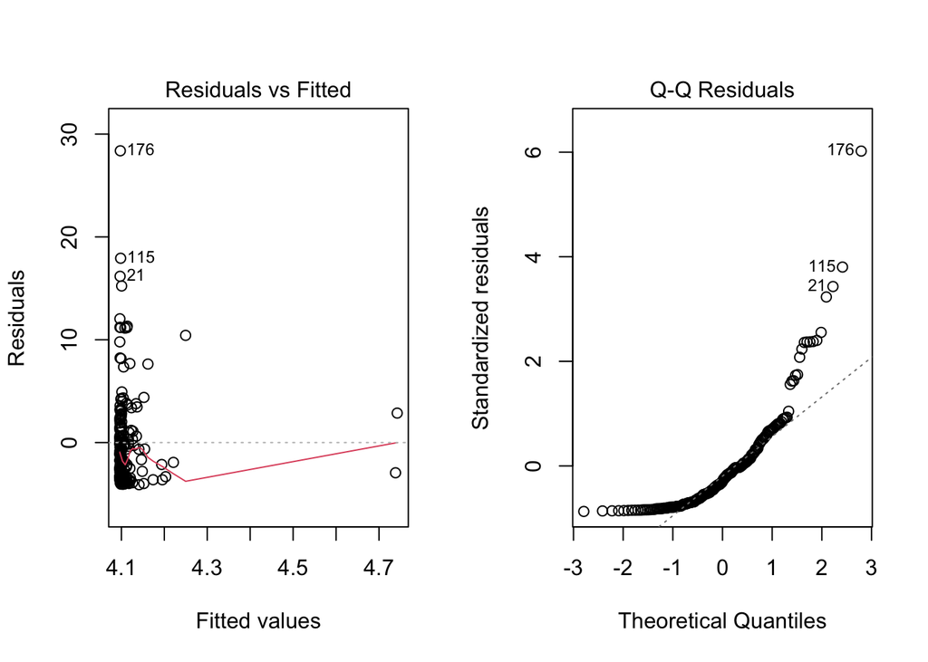

```r
par(mfrow=c(1,2))
plot(fit,which=1)
plot(fit,which=2)
```

```r
par(mfrow=c(1,1))
paired_interp <- merged_interp[complete.cases(merged_interp[c("X2022.Population","X2019")]),]
cat("Observed-data Pearson:",cor(paired$X2022.Population,paired$X2019),"\n")
```

```
Observed-data Pearson: 0.01446026
```

```r
cat("Interpolated-series Pearson:",cor(paired_interp$X2022.Population,paired_interp$X2019),"\n")
```

```
Interpolated-series Pearson: 0.01446026
```

The CO2 values are per person, not total emissions. I used the correlation and regression to look for a pattern, not to prove that population causes emissions.

# Compare continents

I compared continents using the available 2019 CO2 values. These are emissions per person, so adding them does not give total emissions for a continent.

```r
continent_sum <- aggregate(X2019 ~ Continent,data=paired,sum)
continent_mean <- aggregate(X2019 ~ Continent,data=paired,mean)
continent_count <- aggregate(X2019 ~ Continent,data=paired,length)
continent_summary <- Reduce(function(a,b)merge(a,b,by="Continent"),list(continent_sum,continent_mean,continent_count))
names(continent_summary) <- c("Continent","Sum_country_per_capita","Mean_country_per_capita","Countries_observed")
continent_summary <- continent_summary[order(-continent_summary$Sum_country_per_capita),]
knitr::kable(continent_summary,digits=3,caption="2019 country-level CO2 per-capita indicators by continent")
```

2019 country-level CO2 per-capita indicators by continent

|  | Continent | Sum_country_per_capita | Mean_country_per_capita | Countries_observed |
| --- | --- | --- | --- | --- |
| 2 | Asia | 290.549 | 6.316 | 46 |
| 3 | Europe | 246.672 | 5.873 | 42 |
| 4 | North America | 96.897 | 4.213 | 23 |
| 1 | Africa | 63.734 | 1.180 | 54 |
| 5 | Oceania | 54.784 | 3.913 | 14 |
| 6 | South America | 33.356 | 2.780 | 12 |

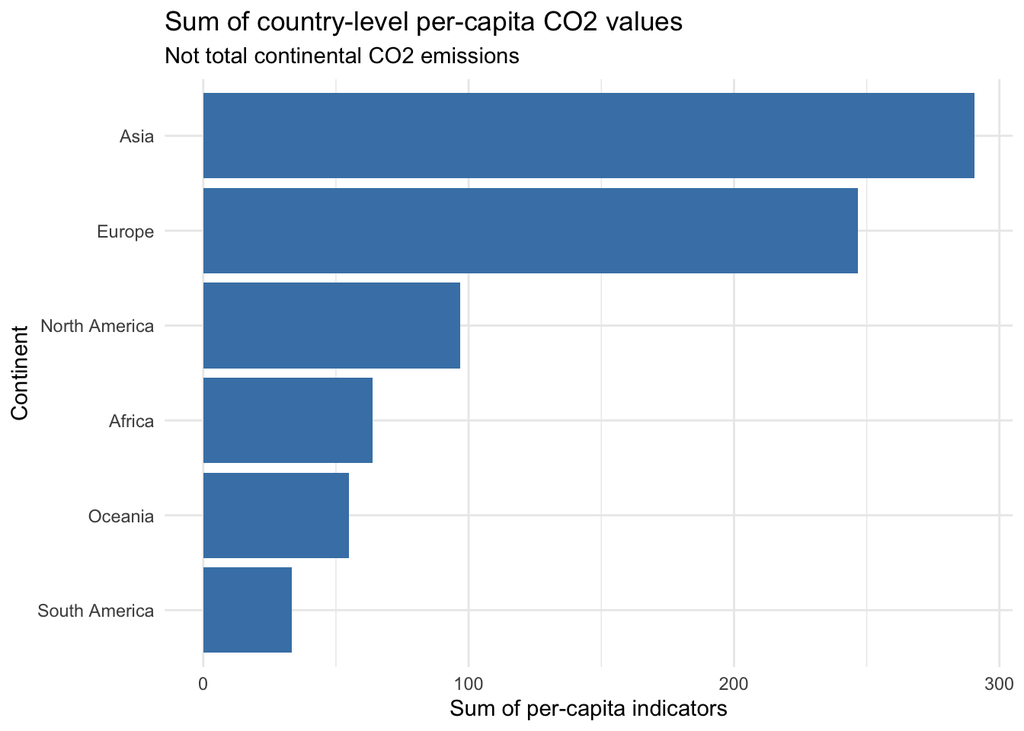

```r
ggplot(continent_summary,aes(reorder(Continent,Sum_country_per_capita),Sum_country_per_capita)) +
 geom_col(fill="steelblue") + coord_flip() +
 labs(title="Sum of country-level per-capita CO2 values",subtitle="Not total continental CO2 emissions",x="Continent",y="Sum of per-capita indicators") + theme_minimal()
```

```r
cat("First:",continent_summary$Continent[1],"\n")
```

```
First: Asia
```

```r
cat("Third:",continent_summary$Continent[3],"value:",continent_summary$Sum_country_per_capita[3],"\n")
```

```
Third: North America value: 96.89692
```

```r
cat("Last:",tail(continent_summary$Continent,1),"value:",tail(continent_summary$Sum_country_per_capita,1),"\n")
```

```
Last: South America value: 33.35583
```

# Conclusion

I found no missing values in the population dataset, but the CO2 dataset had some gaps. I kept valid outliers and used the available values for the main analysis. The 2030 figures are estimates, and the CO2 results should be interpreted carefully because they are per-person values from 2019.